# On the Discrete Choice of Health Care Providers

Part 2: Estimating on Simulated Data

Health Economics

Author

John A. Graves, Ph.D.

Published

January 20, 2023

Funding for this work is graciously acknowledged from Arnold Ventures.

# Introduction

## Parameterize the Data Generation Process

Our first step is to define the data generation process. We begin with location data on 22 ZIP codes and 101 hospitals in Tennessee. The latitude and longitude coordinates of each are provided in the code below. This information will be used later when we calculate distances between patient $i$’s residential geography $g(i)$ and each hospital $h$ in the choice set.

**Setup R Session**

```r
needed_packages <- c("tidyverse","glue","progress","here","evd","geosphere","mlogit","dfidx",
                     "Formula","hrbrthemes","survival","furrr","progressr","tictoc","mcreplicate",
                     "flextable", "broom")

have <- rownames(installed.packages())
needed <- setdiff(needed_packages, have)

please_install <- function(pkgs, install_fun = install.packages) {

    if (length(pkgs) == 0) {
        return(invisible())
    }
    if (!interactive()) {
        stop("Please run in interactive session", call. = FALSE)
    }

    title <- paste0(
        "Ok to install these packges?\n",
        paste("* ", pkgs, collapse = "\n")
    )
    ok <- menu(c("Yes", "No"), title = title) == 1

    if (!ok) {
        return(invisible())
    }

    install_fun(pkgs,dependencies=TRUE)
}
please_install(needed)
x <- suppressMessages(lapply(needed_packages, require, character.only = TRUE))

options("scipen" = 100, "digits" = 5)
select <- dplyr::select

map_progress <- function(.x, .f, ..., .id = NULL) {
    # Source: https://www.jamesatkins.net/post/2020/progress-bar-in-purrrmap_df/
    .f <- purrr::as_mapper(.f, ...)
    pb <- progress::progress_bar$new(total = length(.x), force = TRUE)

    f <- function(...) {
        pb$tick()
        .f(...)
    }
    purrr::map(.x, f, ..., .id = .id)
}


map_multicore <- function(.x, .f, ..., .id = NULL) {
    .f <- purrr::as_mapper(.f, ...)
    p <- progressor(steps = length(.x))
    f <- function(...) {
        p()
        .f(...)
    }
    furrr::future_map(.x, f, ..., .id = .id)
}
```

**Location data code**

```r
df_aha <-
    tibble::tribble(
        ~hosp_x, ~hosp_y, ~hosp_id,
        -87.0657, 36.2772,       1L,
        -86.8092, 36.1537,       2L,
        -86.3273, 36.2207,       3L,
        -85.7428, 35.7001,       4L,
        -84.6072, 35.4408,       5L,
        -85.2674, 35.0345,       6L,
        -82.5143, 36.5509,       7L,
        -89.7143, 35.0494,       8L,
        -85.2604, 35.0413,       9L,
        -86.8037, 36.1417,      10L,
        -81.7977, 36.4534,      11L,
        -86.5656, 35.9751,      12L,
        -89.8005,  35.207,      13L,
        -86.8035, 36.1551,      14L,
        -88.9997, 35.2668,      15L,
        -82.2567, 36.5857,      16L,
        -83.2152, 36.5334,      17L,
        -86.6081, 36.1764,      18L,
        -84.8694, 35.1775,      19L,
        -85.2906,  35.049,      20L,
        -88.1081, 36.0551,      21L,
        -85.9501, 36.2634,      22L,
        -87.4591, 35.7794,      23L,
        -87.2705,  36.582,      24L,
        -87.0665,  35.607,      25L,
        -85.5094, 36.1712,      26L,
        -89.6782, 35.5359,      27L,
        -85.0186, 35.9392,      28L,
        -84.9819, 35.5307,      29L,
        -87.3757, 36.0734,      30L,
        -82.2499, 36.3461,      31L,
        -89.3799,  36.048,      32L,
        -82.4127, 36.1334,      33L,
        -86.5554, 35.1496,      34L,
        -86.818,  35.916,      35L,
        -86.4325, 36.3908,      36L,
        -82.7904, 36.1741,      37L,
        -82.846, 36.1514,      38L,
        -84.556, 35.8884,      39L,
        -86.1682, 36.3878,      40L,
        -83.5191, 36.1065,      41L,
        -84.128,  36.576,      42L,
        -82.3842, 36.3077,      43L,
        -82.5548,  36.554,      44L,
        -82.4022, 36.3361,      45L,
        -83.9366, 35.9575,      46L,
        -84.1007, 35.9172,      47L,
        -83.9482, 35.9347,      48L,
        -86.0248, 36.5192,      49L,
        -84.1118, 36.3889,      50L,
        -87.3387,  35.219,      51L,
        -86.7857,  35.464,      52L,
        -88.3986, 35.6553,      53L,
        -85.3284, 36.3847,      54L,
        -87.8639, 35.5922,      55L,
        -84.27,  35.825,      56L,
        -86.084, 35.4687,      57L,
        -88.8686, 36.3347,      58L,
        -83.9587, 35.7565,      59L,
        -89.8586, 35.1287,      60L,
        -90.0319, 35.1426,      61L,
        -86.6216,  36.325,      62L,
        -90.0259, 35.1437,      63L,
        -90.0194, 35.1368,      64L,
        -89.9322, 35.0672,      65L,
        -89.8646, 35.0981,      66L,
        -88.7535, 35.9133,      67L,
        -83.3056, 36.2131,      68L,
        -82.3731, 36.3112,      69L,
        -86.4251, 35.8609,      70L,
        -86.8025, 36.1539,      71L,
        -86.8071, 36.1668,      72L,
        -86.7572, 36.2409,      73L,
        -86.7215, 36.0764,      74L,
        -86.8445, 36.1293,      75L,
        -86.8018, 36.1413,      76L,
        -83.1821, 35.9644,      77L,
        -84.2455, 36.0243,      78L,
        -88.3106, 36.2965,      79L,
        -88.1232,  35.636,      80L,
        -85.1935, 35.6043,      81L,
        -87.0061,  35.192,      82L,
        -83.0144, 36.3999,      83L,
        -88.2303, 35.2285,      84L,
        -83.5357, 35.8558,      85L,
        -86.0898, 35.1763,      86L,
        -86.4488, 35.5636,      87L,
        -85.4783, 35.9489,      88L,
        -86.8871, 36.4782,      89L,
        -84.4643, 35.6002,      90L,
        -83.5725, 36.4529,      91L,
        -86.2316, 35.3822,      92L,
        -89.0447, 36.4144,      93L,
        -87.795, 36.0785,      94L,
        -87.7564, 35.3252,      95L,
        -86.0721, 35.8326,      96L,
        -88.832, 35.6367,      97L,
        -87.6896, 36.3202,      98L,
        -88.412, 36.0229,      99L,
        -85.8295, 35.9615,     100L,
        -84.5159, 36.5044,     101L
    )

loc <-
    tibble::tribble(
        ~zip,        ~y,         ~x,
        37206L, 36.180173, -86.742066,
        37207L,  36.22225, -86.775085,
        37208L, 36.176866,  -86.80786,
        37209L, 36.148024, -86.869685,
        37210L,  36.13844, -86.739265,
        37211L, 36.067522, -86.721219,
        37212L, 36.135333,  -86.79993,
        37213L, 36.169674, -86.769617,
        37214L, 36.165693,  -86.65909,
        37215L, 36.096895, -86.824092,
        37216L, 36.212995, -86.726085,
        37217L, 36.107141, -86.668089,
        37218L, 36.207631, -86.846454,
        37219L, 36.164516, -86.781539,
        37220L, 36.066135, -86.772465,
        37221L, 36.068319, -86.949648,
        37228L,  36.19026, -86.804031,
        37240L, 36.144748, -86.805258,
        37201L, 36.166419, -86.778182,
        37203L, 36.146286, -86.792457,
        37204L,  36.11175, -86.784663,
        37205L, 36.113509, -86.862533
    ) %>%
    mutate(zip = paste0(zip))
location_ <- unique(loc$zip)
```

We next paramaterize the data generation process (DGP). The parameter vector `mu` includes the “true” value of the coefficients that will later govern our DGP. We assume that in addition to distance from home, patients highly value hospital quality ($Q_h$) in their selections. In addition, patient attributes ($X_i$) also inform hospital choice, though to a lesser extent.

Later, we will conceptualize the idea of a provider network exerting additional frictions on the choice of hospital; this will come into play with the parameters on out-of-network HMO and PPO plans.

```r
params <- list(
    N = 1000,              # Number of patients
    H = nrow(df_aha) ,     # Number of hospitals
    J = 20,                # Number of plans
    K = 10      ,          # Number of networks
    mu = list(intercept = 1,
              mu_x_i = 0.5,  # coef on patient attribute
              mu_q_h = 6,    # coef on hospital attribute
              mu_d_gh = -1,  # coef of distance
              mu_hmo_not_in_network = 5,  # coef on out-of-network HMO
              mu_ppo_not_in_network = 3)  # coef on out-of-network PPO
)
```

## Define the Data Generation Process

We begin by specifying a discrete choice model for patient $i$ selecting hospital $h$. We first consider the case where the patient is unrestricted by a provider network (e.g., as in traditional Medicare); Using a standard random utility framework, we specify the patient’s utility as

$$u_{i h}=\alpha_0+\alpha_1 X_i+\alpha_2 Q_h+\alpha_3 \log \left(t_{i h}\right)+v_{i h}
\tag{1}$$
where $X_i \sim N(0,1)$ capture patient-level attributes (e.g., demographics, comorbidities, etc.), $Q_h\sim N(0,1)$ capture hospital-level attributes (e.g., measures of clinical quality), $t_{ih} = D_{g(i)h}^2$, the squared distance/travel time ($D_{g(i)h}$) between patient $i$’s geographic location (i.e., $g(i)$) and $h$, and $v_{ih}$ is an idiosyncratic error term.

**Define functions to generate hospital attributes and distance.**

```r
generate_hospital_attributes <- function(params) {
 with(params,{
        # Hospital-level variables
            data.frame(hosp_id = 1:H, q_h = rnorm(H,0,1)) %>%
            mutate(q_h = percent_rank(q_h)) %>%
            as_tibble()
 })
}

hosp_ <- params %>% generate_hospital_attributes()

generate_distance_data <- function(params, hosp_data) {
     with(params,{
     crossing(zip = loc$zip ,hosp_id = hosp_data$hosp_id) %>%
            as_tibble() %>%
            left_join(loc,"zip") %>%
            left_join(df_aha,"hosp_id") %>%
            rowwise() %>%
            mutate(dist = as.vector(distm(c(x,y),c(hosp_x,hosp_y), fun = distHaversine)*0.000621371)) %>%
            select(zip,hosp_id,dist) %>%
            set_names(c("zip","hosp_id","d_gh")) %>%
            data.frame() %>%
            dplyr::filter(d_gh < 50000) %>%
            as_tibble()
     })
}

dist_ <- params %>% generate_distance_data(hosp_data = hosp_)
```

Later on, we’ll consider the role of provider networks in shaping hospital choice. To do this, we’ll assume patients are randomly assigned to one of 20 health plans that share 10 total provider networks.[^1] Health plans offer both generous out-of-network coverage (“PPO”) or restrictive out-of-network coverage (“HMO”).

<sup>1</sup> It is not uncommon for health plans to share the same network and differentiate across other dimensions (e.g., deductibles and cost-sharing).

**Define functions to generate network and plan attributes**

```r
generate_network_data <- function(params, hosp_data) {
     with(params,{
       net_0 <-
            tibble(network_id = paste0("K_",1:K)) %>%
            crossing(hosp_id = hosp_data$hosp_id)  %>%
            left_join(hosp_, "hosp_id") %>%
            ########################################################################################
            # NETWORK SELECTION MODEL: HIGHER QUALITY HOSPITALS ARE MORE LIKELY TO BE IN-NETWORK
            ########################################################################################
            mutate(xb = -2 + q_h + rnorm(n(),mean=2,sd=1)) %>%
                mutate(pr_in = boot::inv.logit(xb)) %>%
                rowwise() %>%
                mutate(in_network = rbinom(1,1,prob = pr_in)) %>%
            ########################################################################################
            select(network_id,hosp_id, in_network) %>%
                ungroup()

        net_ <-
            net_0 %>%
            left_join(
                net_0 %>%
                    left_join(hosp_data,"hosp_id") %>%
                    filter(in_network==1) %>%
                    group_by(network_id) %>%
                    summarise(net_qual_list = mean(q_h)),"network_id"
            )
    return(net_)
     })

}

net_ <- params %>% generate_network_data(hosp_data = hosp_)

generate_plan_data <- function(params, network_data) {
     with(params,{

        breadth <-
            net_ %>%
            group_by(network_id) %>%
            summarise(breadth = mean(in_network)) %>%
            mutate(narrower = as.integer(percent_rank(breadth)<.5))

        hmo_nets <- breadth[breadth$narrower==1,]$network_id
        ppo_nets <- breadth[breadth$narrower==0,]$network_id

        plan <-
            tibble(plan_id = paste0("P_",1:J)) %>%
            rowwise() %>%
            mutate(type = sample(c("HMO","PPO"),1,prob = c(.75, 0.25))) %>%
            mutate(network_id = ifelse(type=="HMO",sample(hmo_nets,1),sample(ppo_nets,1)))

        return(plan)
     })
}

plan_ <- params %>% generate_plan_data(network_data = net_)
```

## Combine Hospital, Patient, Plan and Network Attributes

**Construct final attribute data**

```r
combine_attributes <- function(params,hosp_data, location_data , dist_data, plan_data, network_data) {
    with(params,{
        df_choice <-
            data.frame(patient_id = 1:N, x_i = rnorm(N,0,1),runif = runif(N,min=0,max=1)) %>%
            as_tibble() %>%
            rowwise() %>%
            # Sample patient residence from ZIPs
            mutate(zip = sample(location_data,size =1, prob = rep(1/length(location_data),length(location_data)))) %>%
            mutate(plan_id = sample(size = 1, x = unique(plan_data$plan_id), prob = rep(1/J,J))) %>%
            left_join(plan_data,"plan_id") %>%
            ###################################################################################################
            ## IN THIS CASE, PATIENTS RANDOMLY SELECT PLAN
            ###################################################################################################
            # Merge in choice set
            left_join(dist_data , "zip", relationship = "many-to-many") %>%
                left_join(hosp_data,"hosp_id") %>%
                left_join(network_data, c("hosp_id","network_id")) %>%
                mutate(not_in_network = 1 - in_network) %>%
                mutate(hmo = as.integer(type=="HMO")) %>%
            select(-runif,-net_qual_list)
        return(df_choice)
    })
}

df_choice <- params %>%
    combine_attributes(
        hosp_data = hosp_,
        location_data = location_,
        dist_data = dist_,
        plan_data = plan_,
        network_data = net_)

df_choice %>%
    head() %>%
    flextable()
```

| patient_id | x_i | zip | plan_id | type | network_id | hosp_id | d_gh | q_h | in_network | not_in_network | hmo |
| --- | --- | --- | --- | --- | --- | --- | --- | --- | --- | --- | --- |
| 1 | -1.011695 | 37204 | P_20 | HMO | K_2 | 1 | 19.418693 | 0.15 | 1 | 0 | 1 |
| 1 | -1.011695 | 37204 | P_20 | HMO | K_2 | 2 | 3.209201 | 0.41 | 0 | 1 | 1 |
| 1 | -1.011695 | 37204 | P_20 | HMO | K_2 | 3 | 26.628719 | 0.91 | 1 | 0 | 1 |
| 1 | -1.011695 | 37204 | P_20 | HMO | K_2 | 4 | 64.946470 | 0.46 | 1 | 0 | 1 |
| 1 | -1.011695 | 37204 | P_20 | HMO | K_2 | 5 | 130.708656 | 0.45 | 0 | 1 | 1 |
| 1 | -1.011695 | 37204 | P_20 | HMO | K_2 | 6 | 113.307674 | 0.92 | 1 | 0 | 1 |

## Calculate Choice Probabilities

Our next step is to draw on the DGP specified in Equation 1 to calculate choice probabilities for each alternative.

### Random Utility Framework

The function `derive_choice_probabilities_utility()` takes as inputs the parameters and data defined above and applies Equation 1 to calculate these probabilities.

**Derive choice probabilities from random utility framework**

```r
derive_choice_probabilities_utility <- function(params, df, network = TRUE) {
    with(params, {
        if (network) {
            df %>%
                mutate(
                    u_ih = mu$intercept + mu$mu_x_i * x_i + mu$mu_q_h * q_h + mu$mu_d_gh * log(d_gh ^2) +
                           mu$mu_d_gh * mu$mu_ppo_not_in_network * not_in_network * (1 - hmo) +
                           mu$mu_d_gh * mu$mu_hmo_not_in_network * not_in_network * hmo
                ) %>%
                mutate(u_ih = exp(u_ih)) %>%
                group_by(patient_id) %>%
                mutate(pr_u = round(u_ih / sum(u_ih),3)) %>%
                arrange(patient_id, desc(pr_u)) %>%
                select(patient_id,hosp_id, u_ih, pr_u)
        } else {
             df %>%
                mutate(
                    u_ih = mu$intercept + mu$mu_x_i * x_i + mu$mu_q_h * q_h + mu$mu_d_gh * log(d_gh^2)
                ) %>%
                mutate(u_ih = exp(u_ih)) %>%
                group_by(patient_id) %>%
                mutate(pr_u = round(u_ih / sum(u_ih),3)) %>%
                arrange(patient_id, desc(pr_u)) %>%
                select(patient_id,hosp_id, u_ih, pr_u)
        }

    })
}

choice_utility <-
    params %>% derive_choice_probabilities_utility(df = df_choice, network = FALSE)
```

### Gravity Model

We have shown in earlier blog posts that the random utility framework (Equation 1) can be cast in terms of a gravity model,

$$F_{i h}=G \frac{\widetilde{X_i}^{\alpha_1} \widetilde{Q_h}^{\alpha_2}}{t_{i h}^{-\alpha_3}}
\tag{2}$$
where $G$ is a normalizing constant, $\widetilde{X_i} = \exp(X_i)$, and $\widetilde{Q_h} = \exp(Q_h)$.

The function `derive_choice_probabilities_gravity()` takes as its inputs the parameters and data defined above and applies Equation 2 to calculate these probabilities.

**Derive choice probabilities from gravity model framework**

```r
derive_choice_probabilities_gravity <- function(params, df, network=TRUE) {
    with(params, {
        if (network) {
            df %>%
                mutate(t_ih = d_gh^2 * exp(mu$mu_hmo_not_in_network * not_in_network * hmo + mu$mu_ppo_not_in_network * not_in_network * (1-hmo))) %>%
                mutate(f_ih = exp(1)*exp(x_i)^mu$mu_x_i*exp(q_h)^mu$mu_q_h /  t_ih^{-mu$mu_d_gh}) %>%
                group_by(patient_id) %>%
                mutate(pr_g = round(f_ih / sum(f_ih),3)) %>%
                arrange(patient_id, desc(pr_g)) %>%
                select(patient_id,hosp_id, t_ih, f_ih, pr_g)
        } else {
            df %>%
                mutate(t_ih = d_gh^2)  %>%
                mutate(f_ih = exp(1)*exp(x_i)^mu$mu_x_i*exp(q_h)^mu$mu_q_h /  t_ih^{-mu$mu_d_gh}) %>%
                group_by(patient_id) %>%
                mutate(pr_g = round(f_ih / sum(f_ih),3)) %>%
                arrange(patient_id, desc(pr_g)) %>%
                select(patient_id,hosp_id, t_ih, f_ih, pr_g)
        }
    })
}

choice_gravity <-
    params %>% derive_choice_probabilities_gravity(df = df_choice, network = FALSE)
```

### Comparison of Choice Probabilities

We now demonstrate the equivalence of these two approaches in Table 2.[^2] We see that the choice probabilities `pr_g` and `pr_u` are identical.

<sup>2</sup> To avoid a large number of rows where the choice probability is low due the hospital being hundreds of miles away, we limit the observations shown in Table 2 to those within a close distance to each patient.

**Construct table**

```r
choice_gravity %>%
    left_join(choice_utility,c("patient_id","hosp_id")) %>%
    filter(pr_g>0.02) %>%
    head(n=10) %>%
    flextable(col_keys = c("patient_id","hosp_id","tmp1","t_ih","f_ih","pr_g","tmp2","u_ih","pr_u")) %>%
    theme_vanilla() %>%
    add_header_row(values = c("","","Gravity","","Random Utility"),colwidths = c(2,1,3,1,2)) %>%
    empty_blanks()
```

Table 2: Comparison of Choice Probabilities Under Random Utility and Gravity Model Frameworks in Simulated Data

| patient_id | hosp_id |  | Gravity t_ih | Gravity f_ih | Gravity pr_g |  | Random Utility u_ih | Random Utility pr_u |
| --- | --- | --- | --- | --- | --- | --- | --- | --- |
| 1 | 10 |  | 5.4230333 | 101.849573 | 0.722 |  | 101.849573 | 0.722 |
| 1 | 75 |  | 12.6517866 | 14.825576 | 0.105 |  | 14.825576 | 0.105 |
| 1 | 74 |  | 18.4426318 | 8.495081 | 0.060 |  | 8.495081 | 0.060 |
| 1 | 14 |  | 10.0987158 | 6.307529 | 0.045 |  | 6.307529 | 0.045 |
| 2 | 10 |  | 5.4230333 | 193.551232 | 0.722 |  | 193.551232 | 0.722 |
| 2 | 75 |  | 12.6517866 | 28.173987 | 0.105 |  | 28.173987 | 0.105 |
| 2 | 74 |  | 18.4426318 | 16.143744 | 0.060 |  | 16.143744 | 0.060 |
| 2 | 14 |  | 10.0987158 | 11.986599 | 0.045 |  | 11.986599 | 0.045 |
| 3 | 74 |  | 0.3773626 | 1,192.202143 | 0.954 |  | 1,192.202143 | 0.954 |
| 3 | 10 |  | 47.5743386 | 33.338572 | 0.027 |  | 33.338572 | 0.027 |

# Simulate

Our data generation functions are now nearly complete. However, after the steps above we have only defined the *probability* that a simulated patient chooses each alternative. We now round our our DGP simulation code by randomly selecting a hospital for each patient based on these probabilities.

The entire process is captured in a function `simulate_dgp()` that simulates data (including hospital choices) under the DGP defined above. The function has an option for which choice framework (random utility, gravity) the data are generated under—though of course, as we saw above, both will yield identical choice probabilities. To be comprehensive, however, we will simulate two datasets with a common random seed to avoid stochastic differences between them: one under the random utility framework (Equation 1) and one dataset under the gravity model framework (Equation 2).

**Data generation process simulation function code**

```r
simulate_dgp <- function(params, has_network = TRUE, max_distance = 50, framework = "gravity") {
    hosp_ <- params %>% generate_hospital_attributes()
    dist_ <- params %>% generate_distance_data(hosp_data = hosp_)
    net_ <- params %>% generate_network_data(hosp_data = hosp_)
    plan_ <- params %>% generate_plan_data(network_data = net_)
    df_choice <- params %>%
        combine_attributes(
            hosp_data = hosp_,
            location_data = location_,
            dist_data = dist_,
            plan_data = plan_,
            network_data = net_)
    if (framework == "gravity") {
        tmp <-
            params %>% derive_choice_probabilities_gravity(df = df_choice, network = has_network)  %>%
            group_by(patient_id) %>%
            mutate(runif = runif(1)) %>%
            mutate(cum_pr = cumsum(pr_g)) %>%
            mutate(cum_pr = ifelse(row_number() == n(), 1, cum_pr)) %>%
            mutate(cum_pr0 = ifelse(row_number() == 1, 0, lag(cum_pr, 1))) %>%
            rowwise() %>%
            mutate(selected = as.integer(between(runif, cum_pr0, cum_pr))) %>%
            ungroup() %>%
            select(patient_id, hosp_id, truth = pr_g, selected)
    } else if (framework == "random_utility") {
        tmp <-
            params %>% derive_choice_probabilities_utility(df = df_choice, network = has_network)  %>%
            group_by(patient_id) %>%
            mutate(runif = runif(1)) %>%
            mutate(cum_pr = cumsum(pr_u)) %>%
            mutate(cum_pr = ifelse(row_number() == n(), 1, cum_pr)) %>%
            mutate(cum_pr0 = ifelse(row_number() == 1, 0, lag(cum_pr, 1))) %>%
            rowwise() %>%
            mutate(selected = as.integer(between(runif, cum_pr0, cum_pr))) %>%
            ungroup() %>%
            select(patient_id, hosp_id, truth = pr_u, selected)
    }

    df_choice %>%
        left_join(tmp,c("patient_id","hosp_id")) %>%
        ungroup() %>%
        filter(d_gh <= max_distance) %>%
        select(patient_id, x_i, zip,hosp_id, q_h, selected, d_gh, not_in_network, hmo, truth) %>%
        group_by(patient_id) %>%
        # Remove individuals whose selected hospital is > max_distance
        mutate(max_choice = max(selected)) %>%
        filter(max_choice == 1) %>%
        select(-max_choice) %>%
        # Remove hospitals that are never chosen
        group_by(hosp_id) %>%
        mutate(max_choice = max(selected)) %>%
        filter(max_choice == 1) %>% ungroup()
}

set.seed(623)
df_gravity <- params %>%
    simulate_dgp(has_network = FALSE, framework = "gravity")
set.seed(623)
df_utility <- params %>%
    simulate_dgp(has_network = FALSE, framework = "random_utility")

# Collect results
df_res <-
    df_gravity %>% select(patient_id,hosp_id,truth)
```

# Estimate

We have several estimation options. First, we will consider the conditional logit as executed using the `mlogit` package in R.

The `mlogit()` command requires that the data first be pre-processed:

```r
df_cl_utility <-
    df_utility %>%
    select(patient_id, hosp_id, selected, d_gh,q_h) %>%
    dfidx(.)
```

We next fit the data with patient and hospital fixed effects.

```r
fit_cl_utility =
    mlogit(selected ~ log(d_gh^2), data =df_cl_utility)
```

**Table code**

```r
fit_cl_utility %>% tidy() %>%
    filter(!grepl("Intercept",term)) %>%
    flextable() %>%
    flextable::add_footer_lines("Note: Coefficients on hospital fixed effects suppressed from table.")
```

| term | estimate | std.error | statistic | p.value |
| --- | --- | --- | --- | --- |
| log(d_gh^2) | -0.9844322 | 0.04904563 | -20.07176 | 0 |

Note: Coefficients on hospital fixed effects suppressed from table.

Another option—to the extent we can measure all relevant hospital-level attributes (which we do here)—is to include hospital-level predictors rather than hospital fixed effects:

```r
fit_clx_utility =
    mlogit(selected ~ log(d_gh^2) + q_h | 0, data =df_cl_utility)
```

**Table code**

```r
fit_clx_utility %>% tidy() %>%
    flextable()
```

| term | estimate | std.error | statistic | p.value |
| --- | --- | --- | --- | --- |
| log(d_gh^2) | -0.9676013 | 0.03306971 | -29.25945 | 0 |
| q_h | 5.7909522 | 0.20274063 | 28.56335 | 0 |

Note that the estimated coefficients are quite close to the “truth” as defined in the `params` object above (i.e., -1 and 6).

We also obtain identical answers using the data simulated under the gravity model framework:

**Fit mlogit using gravity model data.**

```r
df_cl_gravity <-
    df_gravity %>%
    select(patient_id, hosp_id, selected, d_gh, q_h) %>%
    dfidx(.)

fit_cl_gravity =
    mlogit(selected ~ log(d_gh^2), data =df_cl_gravity)

fit_cl_gravity %>% tidy() %>%
    filter(!grepl("Intercept",term)) %>%
    flextable() %>%
    flextable::add_footer_lines("Note: Coefficients on hospital fixed effects suppressed from table.")
```

| term | estimate | std.error | statistic | p.value |
| --- | --- | --- | --- | --- |
| log(d_gh^2) | -0.9844322 | 0.04904563 | -20.07176 | 0 |

Note: Coefficients on hospital fixed effects suppressed from table.

**Fit mlogit using gravity model data.**

```r
fit_clx_gravity =
    mlogit(selected ~ log(d_gh^2) + q_h | 0, data =df_cl_gravity)

fit_clx_gravity %>% tidy() %>%
    flextable()
```

| term | estimate | std.error | statistic | p.value |
| --- | --- | --- | --- | --- |
| log(d_gh^2) | -0.9676013 | 0.03306971 | -29.25945 | 0 |
| q_h | 5.7909522 | 0.20274063 | 28.56335 | 0 |

## Discrete Choice Using Cox Proportional Hazard Models

It has been shown (Gail, Lubin, and Rubinstein (1981)) that the log-likelihood of a conditional logit is equivalent to that of a Cox proportional hazards model under a specific data structure. Intuitively, we can think of our choice problem as a matched case-control study where the cases are the chosen hospitals and the controls are the unchosen hospitals. We can re-cast our data as a case-control at a single time point, and fit a Cox proportional hazards model to estimate the instantaneous “hazard” of selecting each alternative as a function of covariates. In addition, we stratify the Cox model by `patient_id`, which is analogous to estimating with patient fixed effects (Allison 2014).

```r
fit_cox_gravity <-
    coxph(
        formula =
            Surv(rep(1, nrow(df_gravity)), selected) ~ factor(hosp_id) + log(d_gh^2) + strata(patient_id),
        data = df_gravity,
        method = "efron",
        robust = TRUE
    )

fit_cox_utility <-
    coxph(
        formula =
            Surv(rep(1, nrow(df_utility)), selected) ~ factor(hosp_id) + log(d_gh^2) + strata(patient_id),
        data = df_utility,
        method = "efron",
        robust = TRUE
    )
```

**Table code**

```r
fit_cox_utility %>%
    tidy() %>%
    filter(!grepl("hosp_id",term)) %>%
    mutate_at(vars(-term),~round(.,3)) %>%
    flextable() %>%
    flextable::add_footer_lines("Note: Coefficients on hospital fixed effects suppressed from table.")
```

| term | estimate | std.error | robust.se | statistic | p.value |
| --- | --- | --- | --- | --- | --- |
| log(d_gh^2) | -0.984 | 0.049 | 0.041 | -23.752 | 0 |

Note: Coefficients on hospital fixed effects suppressed from table.

Table 3 summarizes all the above and shows clearly that the gravity model and random utility frameworks–as estimated with a conditional logit *or* using a Cox model, yield identical coefficient values.

**Construct table**

```r
# Note: mlogit::mlogit() does not handle predicted values super well (which we'll look at later), so re-fitting using survival::clogit() instead; this yields identical results.

fit_cl_gravity <-
    clogit(selected ~ factor(hosp_id) + log(d_gh^2) + strata(patient_id),
           data = df_gravity,
           method=c("efron"),
           robust = TRUE)
df_res$cl_gravity <- predict(fit_cl_gravity,type="expected")

fit_clx_gravity <-
    clogit(selected ~  q_h + log(d_gh^2) + strata(patient_id) ,
           data = df_gravity,
           method = c("efron"),
           robust = TRUE)

fit_cl_utility <-
    clogit(selected ~ factor(hosp_id) + log(d_gh^2) + strata(patient_id),
           data = df_utility,
           method=c("efron"),
           robust = TRUE)
df_res$cl_utility <- predict(fit_cl_utility,type="expected")

fit_clx_utility <-
    clogit(selected ~  q_h + log(d_gh^2) + strata(patient_id) ,
           data = df_utility,
           method = c("efron"),
           robust = TRUE)

fit_coxX_gravity <-
    coxph(
        formula =
            Surv(rep(1, nrow(df_gravity)), selected) ~ q_h + log(d_gh^2) + strata(patient_id),
        data = df_gravity,
        method = "efron",
        robust = TRUE
    )

fit_coxX_utility <-
    coxph(
        formula =
            Surv(rep(1, nrow(df_gravity)), selected) ~ q_h + log(d_gh^2) + strata(patient_id),
        data = df_utility,
        method = "efron",
        robust = TRUE
    )


res_cl_gravity <- fit_cl_gravity %>% tidy() %>%
    filter(grepl("d_gh|q_h",term)) %>%
    select(term, estimate,se = std.error) %>%
    mutate(hosp_fixed = "X", patient_fixed = "X", framework = "Gravity", spec = "CL")  %>%
    mutate(estimate = glue("{round(estimate,3)}")) %>%
    mutate(se = glue("({round(se,3)})"))  %>%
    mutate(n = row_number(), N = n()) %>%
    gather(measure,value,-term,-n,-N) %>%
    filter(measure == "estimate" | measure=="se" | (measure !="estimate" & measure != "se" & (n==N))) %>%
    mutate(term = ifelse(measure!="estimate" & measure!="se","",term))           %>%
    mutate(term = factor(term)) %>%
    mutate(term = fct_relevel(term,"log(d_gh^2)")) %>%
    arrange(term,measure) %>%
    mutate(measure = factor(measure, levels = c("estimate","se","hosp_fixed","patient_fixed","framework","spec"))) %>%
    arrange(term,measure) %>%
    rename(cl_gravity = value) %>%
    select(-n,-N)


res_clx_gravity <- fit_clx_gravity %>% tidy() %>%
    filter(grepl("d_gh|q_h",term)) %>%
    select(term, estimate,se = std.error) %>%
    mutate(hosp_fixed = "-", patient_fixed = "X", framework = "Gravity", spec = "CL")  %>%
    mutate(estimate = glue("{round(estimate,3)}")) %>%
    mutate(se = glue("({round(se,3)})"))  %>%
    mutate(n = row_number(), N = n()) %>%
    gather(measure,value,-term,-n,-N) %>%
    filter(measure == "estimate" | measure=="se" | (measure !="estimate" & measure != "se" & (n==N))) %>%
    mutate(term = ifelse(measure!="estimate" & measure!="se","",term))           %>%
    mutate(term = factor(term)) %>%
    mutate(term = fct_relevel(term,"q_h")) %>%
    mutate(term = fct_relevel(term,"log(d_gh^2)")) %>%
    arrange(term,measure) %>%
    mutate(measure = factor(measure, levels = c("estimate","se","hosp_fixed","patient_fixed","framework","spec"))) %>%
    arrange(term,measure) %>%
    rename(clx_gravity = value) %>%
    select(-n,-N)

res_cox_gravity <- fit_cox_gravity %>% tidy() %>%
    filter(grepl("d_gh|q_h",term)) %>%
    select(term, estimate,se = robust.se) %>%
    mutate(hosp_fixed = "X", patient_fixed = "X", framework = "Gravity", spec = "Cox")  %>%
    mutate(estimate = glue("{round(estimate,3)}")) %>%
    mutate(se = glue("({round(se,3)})"))  %>%
    mutate(n = row_number(), N = n()) %>%
    gather(measure,value,-term,-n,-N) %>%
    filter(measure == "estimate" | measure=="se" | (measure !="estimate" & measure != "se" & (n==N))) %>%
    mutate(term = ifelse(measure!="estimate" & measure!="se","",term))           %>%
    mutate(term = factor(term)) %>%
    mutate(term = fct_relevel(term,"log(d_gh^2)")) %>%
    arrange(term,measure) %>%
    mutate(measure = factor(measure, levels = c("estimate","se","hosp_fixed","patient_fixed","framework","spec"))) %>%
    arrange(term,measure) %>%
    rename(cox_gravity = value) %>%
    select(-n,-N)

res_cl_utility <-
    fit_cl_utility %>% tidy() %>%
    filter(grepl("d_gh|q_h",term)) %>%
    select(term, estimate,se = std.error) %>%
    mutate(hosp_fixed = "X", patient_fixed = "X", framework = "Random Utility", spec = "CL")  %>%
    mutate(estimate = glue("{round(estimate,3)}")) %>%
    mutate(se = glue("({round(se,3)})"))  %>%
    mutate(n = row_number(), N = n()) %>%
    gather(measure,value,-term,-n,-N) %>%
    filter(measure == "estimate" | measure=="se" | (measure !="estimate" & measure != "se" & (n==N))) %>%
    mutate(term = ifelse(measure!="estimate" & measure!="se","",term))           %>%
    mutate(term = factor(term)) %>%
    mutate(term = fct_relevel(term,"log(d_gh^2)")) %>%
    arrange(term,measure) %>%
    mutate(measure = factor(measure, levels = c("estimate","se","hosp_fixed","patient_fixed","framework","spec"))) %>%
    arrange(term,measure) %>%
    rename(cl_utility = value) %>%
    select(-n,-N)

res_cox_utility <-
    fit_cox_utility %>% tidy() %>%
    filter(grepl("d_gh|q_h",term)) %>%
    select(term, estimate,se = robust.se) %>%
    mutate(hosp_fixed = "X", patient_fixed = "X", framework = "Random Utility", spec = "Cox")  %>%
    mutate(estimate = glue("{round(estimate,3)}")) %>%
    mutate(se = glue("({round(se,3)})"))  %>%
    mutate(n = row_number(), N = n()) %>%
    gather(measure,value,-term,-n,-N) %>%
    filter(measure == "estimate" | measure=="se" | (measure !="estimate" & measure != "se" & (n==N))) %>%
    mutate(term = ifelse(measure!="estimate" & measure!="se","",term))           %>%
    mutate(term = factor(term)) %>%
    mutate(term = fct_relevel(term,"log(d_gh^2)")) %>%
    arrange(term,measure) %>%
    mutate(measure = factor(measure, levels = c("estimate","se","hosp_fixed","patient_fixed","framework","spec"))) %>%
    arrange(term,measure) %>%
    rename(cox_utility = value) %>%
    select(-n,-N)

res_coxX_utility <- fit_coxX_utility %>% tidy() %>%
    filter(grepl("d_gh|q_h",term)) %>%
    select(term, estimate,se = std.error) %>%
    mutate(hosp_fixed = "-", patient_fixed = "X", framework = "Random Utility", spec = "Cox")  %>%
    mutate(estimate = glue("{round(estimate,3)}")) %>%
    mutate(se = glue("({round(se,3)})"))  %>%
    mutate(n = row_number(), N = n()) %>%
    gather(measure,value,-term,-n,-N) %>%
    filter(measure == "estimate" | measure=="se" | (measure !="estimate" & measure != "se" & (n==N))) %>%
    mutate(term = ifelse(measure!="estimate" & measure!="se","",term))           %>%
    mutate(term = factor(term)) %>%
    mutate(term = fct_relevel(term,"q_h")) %>%
    mutate(term = fct_relevel(term,"log(d_gh^2)")) %>%
    arrange(term,measure) %>%
    mutate(measure = factor(measure, levels = c("estimate","se","hosp_fixed","patient_fixed","framework","spec"))) %>%
    arrange(term,measure) %>%
    rename(coxX_utility = value) %>%
    select(-n,-N)

res_coxX_gravity <- fit_coxX_gravity %>% tidy() %>%
    filter(grepl("d_gh|q_h",term)) %>%
    select(term, estimate,se = std.error) %>%
    mutate(hosp_fixed = "-", patient_fixed = "X", framework = "Gravity", spec = "Cox")  %>%
    mutate(estimate = glue("{round(estimate,3)}")) %>%
    mutate(se = glue("({round(se,3)})"))  %>%
    mutate(n = row_number(), N = n()) %>%
    gather(measure,value,-term,-n,-N) %>%
    filter(measure == "estimate" | measure=="se" | (measure !="estimate" & measure != "se" & (n==N))) %>%
    mutate(term = ifelse(measure!="estimate" & measure!="se","",term))           %>%
    mutate(term = factor(term)) %>%
    mutate(term = fct_relevel(term,"q_h")) %>%
    mutate(term = fct_relevel(term,"log(d_gh^2)")) %>%
    arrange(term,measure) %>%
    mutate(measure = factor(measure, levels = c("estimate","se","hosp_fixed","patient_fixed","framework","spec"))) %>%
    arrange(term,measure) %>%
    rename(coxX_gravity = value) %>%
    select(-n,-N)

res_clx_utility <- fit_clx_utility %>% tidy() %>%
    filter(grepl("d_gh|q_h",term)) %>%
    select(term, estimate,se = std.error) %>%
    mutate(hosp_fixed = "-", patient_fixed = "X", framework = "Random Utility", spec = "CL")  %>%
    mutate(estimate = glue("{round(estimate,3)}")) %>%
    mutate(se = glue("({round(se,3)})"))  %>%
    mutate(n = row_number(), N = n()) %>%
    gather(measure,value,-term,-n,-N) %>%
    filter(measure == "estimate" | measure=="se" | (measure !="estimate" & measure != "se" & (n==N))) %>%
    mutate(term = ifelse(measure!="estimate" & measure!="se","",term))           %>%
    mutate(term = factor(term)) %>%
    mutate(term = fct_relevel(term,"q_h")) %>%
    mutate(term = fct_relevel(term,"log(d_gh^2)")) %>%
    arrange(term,measure) %>%
    mutate(measure = factor(measure, levels = c("estimate","se","hosp_fixed","patient_fixed","framework","spec"))) %>%
    arrange(term,measure) %>%
    rename(clx_utility = value) %>%
    select(-n,-N)

res_table <-
    res_cl_gravity %>%
    full_join(res_clx_gravity,c("term","measure")) %>%
    full_join(res_cox_gravity,c("term","measure")) %>%
    full_join(res_cl_utility,c("term","measure")) %>%
    full_join(res_cox_utility,c("term","measure")) %>%
    full_join(res_clx_utility,c("term","measure")) %>%
    full_join(res_coxX_gravity,c("term","measure")) %>%
    full_join(res_coxX_utility,c("term","measure")) %>%
    select(term,measure,cl_gravity,cl_utility,cox_gravity,cox_utility,clx_gravity,clx_utility,coxX_gravity,coxX_utility) %>%
    mutate(measure = factor(measure, levels = c("estimate","se","hosp_fixed","patient_fixed","framework","spec"))) %>%
    mutate(term = factor(term)) %>%
    mutate(term = fct_relevel(term,"q_h")) %>%
    mutate(term = fct_relevel(term,"log(d_gh^2)")) %>%
    arrange(term,measure) %>%
    select(measure,term,everything()) %>%

    mutate(measure = factor(measure)) %>%
    mutate(measure = fct_recode(measure,  "Hospital Fixed Effects" = "hosp_fixed", "Patient Fixed Effects" = "patient_fixed",
                                "Choice Framework for Data Generation Process" = "framework", "Specification" = "spec")) %>%
    mutate(measure = coalesce(measure,term)) %>%
    mutate(term = ifelse(measure=="se","",paste0(term))) %>%
    mutate(measure = ifelse(measure %in% c("estimate","se"),"",paste0(measure))) %>%
    mutate(measure = paste0(measure,term)) %>%
    select(-term)

res_table %>%
    mutate(Truth = with(params, sprintf("%.1f",c(mu$mu_d_gh,NA,mu$mu_q_h,NA,NA,NA,NA,NA)))) %>%
    mutate(Truth = ifelse(is.na(Truth)|Truth=="NA","",Truth)) %>%
    mutate(measure = ifelse(measure == "log(d_gh^2)","ln(Distance-squared)",measure)) %>%
    mutate(measure = ifelse(measure == "q_h","Hospital quality composite",measure)) %>%
    flextable() %>%
    width(j = 1, width=2)  %>%
    set_header_labels(
    measure = "",
    cl_gravity= "(1)",
    cl_utility = "(2)",
    cox_gravity = "(3)",
    cox_utility = "(4)",
    clx_gravity = "(5)",
    clx_utility = "(6)",
    coxX_gravity = "(7)",
    coxX_utility = "(8)") %>%
    add_footer_lines(c("Standard errors shown in parentheses; CL = Conditional logit; distance measured in miles"))
```

Table 3: Comparison of Estimates Under Alternative Data Generation (Gravity, Random Utility) Processes and Estimation (conditional logit, Cox) Approaches

|  | (1) | (2) | (3) | (4) | (5) | (6) | (7) | (8) | Truth |
| --- | --- | --- | --- | --- | --- | --- | --- | --- | --- |
| ln(Distance-squared) | -0.984 | -0.984 | -0.984 | -0.984 | -0.968 | -0.968 | -0.968 | -0.968 | -1.0 |
|  | (0.049) | (0.049) | (0.041) | (0.041) | (0.033) | (0.033) | (0.033) | (0.033) |  |
| Hospital quality composite |  |  |  |  | 5.791 | 5.791 | 5.791 | 5.791 | 6.0 |
|  |  |  |  |  | (0.203) | (0.203) | (0.203) | (0.203) |  |
| Hospital Fixed Effects | X | X | X | X | - | - | - | - |  |
| Patient Fixed Effects | X | X | X | X | X | X | X | X |  |
| Choice Framework for Data Generation Process | Gravity | Random Utility | Gravity | Random Utility | Gravity | Random Utility | Gravity | Random Utility |  |
| Specification | CL | CL | Cox | Cox | CL | CL | Cox | Cox |  |

Standard errors shown in parentheses; CL = Conditional logit; distance measured in miles

We next verify that each framework and specification yield identical predicted choice probabilities, and these choice probabilties are centered around the “truth” from the underlying DGP:

**Construct figure**

```r
baseline_hazard_gravity <- basehaz(fit_cox_gravity) %>% as_tibble() %>% janitor::clean_names() %>% select(-time) %>% rename(hazard_gravity = hazard, strata_gravity = strata)
baseline_hazard_utility <- basehaz(fit_cox_gravity) %>% as_tibble() %>% janitor::clean_names() %>% select(-time) %>% rename(hazard_utility = hazard,
                                                                                                                            strata_utility = strata)
df_res$lp_cox_gravity <- predict(fit_cox_gravity, type = "lp")
df_res$lp_cox_utility <- predict(fit_cox_utility, type = "lp")
df_res$strata_gravity = model.frame(fit_cox_gravity) %>% as_tibble() %>% janitor::clean_names() %>% pull(strata_patient_id)
df_res$strata_utility = model.frame(fit_cox_utility) %>% as_tibble() %>% janitor::clean_names() %>% pull(strata_patient_id)
df_res <-
    df_res %>% left_join(baseline_hazard_gravity,"strata_gravity") %>%
    left_join(baseline_hazard_utility,"strata_utility")

foo <-
    df_res %>%
    mutate(cox_gravity = exp(lp_cox_gravity)*hazard_gravity) %>%
    mutate(cox_utility = exp(lp_cox_utility)*hazard_utility) %>%
    group_by(patient_id) %>%
    mutate(cox_gravity = cox_gravity/sum(cox_gravity))  %>%
    mutate(cox_utility = cox_utility/sum(cox_utility))  %>%
    select(patient_id,hosp_id,truth,cl_gravity,cl_utility,cox_gravity,cox_utility)

foo %>%
    gather(model,p_choice,-patient_id,-hosp_id,-truth) %>%
    mutate(model = case_when(model=="cl_gravity" ~ "Conditional Logit - Gravity",
                             model=="cl_utility" ~ "Conditional Logit - Random Utillity",
                             model=="cox_gravity" ~ "Cox Proportional Hazards - Gravity",
                             model=="cox_utility" ~ "Cox Proportional Hazards - Random Utility")) %>%
    ggplot(aes(x = truth, y = p_choice, colour = model)) + #geom_smooth() +
    hrbrthemes::theme_ipsum() +
    geom_abline(intercept = 0, slope = 1, lty=2) +
    theme(legend.position = "bottom") +
    ggsci::scale_colour_nejm(name="") +
    labs(x = "Chioce Probability: Truth", y = "Choice Probability: Prediccted") +
    geom_point(alpha=0.2)
```

Table 4: Predicted Choice Probabilities vs. Truth

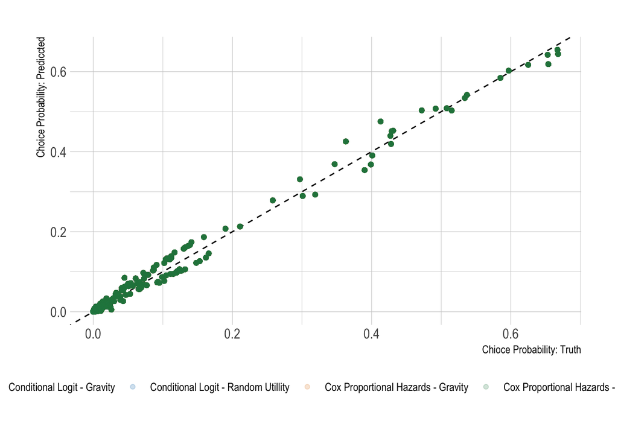

# Adding Choice Frictions From Plan Networks

In this section, we will augment the data generation process by conceptualizing more vs. restrictive plan networks as sources of friction on patient choices. Intuitively, a patient may otherwise value the proximity and quality of a hospital. However, if the hospital is out-of-network—requiring the patient to pay the full bill (HMO) or a substantially higher share of the bill (PPO)— the hospital may as well be 1,000 miles away.

We will conceptualize the above intutiion by adapting the distance function in the denominator of Equation 2.

Frictions enter a gravity model through the denominator term $t_{i h}$, which we rewrite as $t_{i h}=$ $D_{i h}^2 \exp \left(\alpha_4\left(1-NET_{ih}\right)\left(1-HMO_{p(i)}\right)+\alpha_5\left(1-NET_{ih}\right) HMO_{p(i)}\right)$, where $NET_{ih}$ is a binary indicator for whether hospital $h$ is NETwork for patient $i$, and $HMO_{p(i)}$ is a binary indicator for whether the patient is enrolled in an HMO plan,

$$F_{i h}=G \frac{\widetilde{X_i}^{\alpha_1} \widetilde{Q_h}^{\alpha_2}}{\big ( D_{i h}^2 \exp \left(\alpha_4\left(1-NET_{ih}\right)\left(1-HMO_{p(i)}\right)+\alpha_5\left(1-NET_{ih}\right) HMO_{p(i)}\right) \big )^{-\alpha_3}}
\tag{3}$$

With the new specification for $t_{ih}$ in hand, we convert back to the (equivalent!) utility scale to obtain,

$$\begin{eqnarray}
u_{i h}&=&\alpha_0+\alpha_1 X_i+\alpha_2 Q_h+\alpha_3 \log \left(D_{i h}^2\right)+ \\ & &\alpha_3 \alpha_4\left(1-NET_{ih}\right)\left(1-HMO_{p(i)}\right)+ \\ && \alpha_3 \alpha_5\left(1-NET_{ih}\right) HMO_{p(i)}+v_{i h}
\end{eqnarray}
\tag{4}$$

To estimate parameters in Equation 4 we will fit conditional logit models of the form:

$$u_{i h}=\delta_h+\gamma_i + \beta_1 \log \left(D_{i h}^2\right)+\beta_2\left(1-NET_{i h}\right)\left(1-\mathrm{HMO}_{p(i)}\right)+\beta_3\left(1-\mathrm{NET}_{ih}\right) \mathrm{HMO}_{p(i)}+\epsilon_{\mathrm{ih}}$$
where $\delta_h$ are hospital fixed effects and $\gamma_i$ are patient fixed effects.

```r
set.seed(623)
df_utility_net <-
    simulate_dgp(params, has_network = TRUE, framework = "random_utility")

df_cl_utility_net <-
    df_utility_net %>%
    select(patient_id, hosp_id, selected, d_gh, q_h, hmo, not_in_network) %>%
    dfidx(.)

fit_cl_utility_net =
    mlogit(selected ~ log(d_gh^2) + I(not_in_network*hmo) + I(not_in_network * (1-hmo)), data =df_cl_utility_net)
```

**Table code**

```r
fit_cl_utility_net %>% tidy() %>%
    filter(!grepl("Intercept",term)) %>%
    mutate_at(vars(estimate,std.error,statistic,p.value),~round(.,3)) %>%
    mutate(p.value = ifelse(p.value<.001,"<0.001",ifelse(p.value<.01,"<0.01",paste0(round(p.value,3))))) %>%
    flextable() %>%
    flextable::add_footer_lines("Note: Coefficients on hospital fixed effects suppressed from table.")
```

| term | estimate | std.error | statistic | p.value |
| --- | --- | --- | --- | --- |
| log(d_gh^2) | -0.993 | 0.054 | -18.323 | <0.001 |
| I(not_in_network * hmo) | -4.684 | 0.715 | -6.551 | <0.001 |
| I(not_in_network * (1 - hmo)) | -3.287 | 0.369 | -8.900 | <0.001 |

Note: Coefficients on hospital fixed effects suppressed from table.

## Parameters of Interest

$$\alpha_4 = \frac{\hat \beta_2}{\hat \beta_1}
\tag{5}$$
$$\alpha_5 = \frac{\hat \beta_3}{\hat \beta_1}
\tag{6}$$

We see in the final column that when network frictions are accounted for, the predicted choice probabilities are much closer to the “truth” from the underlying DGP.

**Model Predictions With and Without Network Frictions**

```r
fit_cl_utility_net0 <-
    clogit(selected ~ factor(hosp_id) + log(d_gh^2) + strata(patient_id),
           data = df_utility_net,
           method=c("efron"),
           robust = TRUE)

fit_cl_utility_net1 <-
    clogit(selected ~ factor(hosp_id) + log(d_gh^2) + I(not_in_network*hmo) +
               I(not_in_network * (1-hmo)) + strata(patient_id),
           data = df_utility_net,
           method=c("efron"),
           robust = TRUE)

df_res_net <-
    df_utility_net %>% select(patient_id,hosp_id,d_gh,not_in_network,hmo,truth) %>%
    mutate(not_in_network = 1 - not_in_network) %>%
    rename(in_network = not_in_network)
df_res_net$cl_utility0 <- predict(fit_cl_utility_net0,type="expected",newdata = df_utility_net)
df_res_net$cl_utility1 <- predict(fit_cl_utility_net1,type="expected",newdata = df_utility_net)

df_res_net %>% filter(d_gh<10) %>% arrange(patient_id,d_gh) %>% filter(patient_id==8) %>%
    mutate_at(vars(starts_with("cl_"),d_gh),~round(.,3)) %>%
    flextable(col_keys = c("patient_id","hosp_id","tmp1","d_gh","in_network","hmo","tmp2","truth","tmp3","cl_utility0","cl_utility1")) %>%
    theme_vanilla() %>%
    empty_blanks() %>%
    add_header_row(
        values = c("Choice Situation","","Patient Attributes","","","Predicted"), colwidths = c(2,1,4,1,1,2)
    ) %>%
     set_header_labels(
      truth = "Truth",
      cl_utility0 = "No Network Frictions",
      cl_utility1 = "Network Frictions"
     )
```

Table 5: Comparison of Predicted Choice Probabilties

| Choice Situation patient_id | Choice Situation hosp_id |  | Patient Attributes d_gh | Patient Attributes in_network | Patient Attributes hmo | Patient Attributes | Truth |  | Predicted No Network Frictions | Predicted Network Frictions |
| --- | --- | --- | --- | --- | --- | --- | --- | --- | --- | --- |
| 8 | 75 |  | 1.912 | 0 | 0 |  | 0.021 |  | 0.167 | 0.015 |
| 8 | 2 |  | 3.401 | 0 | 0 |  | 0.011 |  | 0.123 | 0.008 |
| 8 | 10 |  | 3.712 | 1 | 0 |  | 0.089 |  | 0.053 | 0.095 |
| 8 | 72 |  | 3.729 | 0 | 0 |  | 0.000 |  | 0.002 | 0.000 |
| 8 | 14 |  | 3.729 | 1 | 0 |  | 0.143 |  | 0.121 | 0.164 |
| 8 | 71 |  | 3.774 | 1 | 0 |  | 0.664 |  | 0.466 | 0.647 |
| 8 | 76 |  | 3.820 | 1 | 0 |  | 0.008 |  | 0.004 | 0.008 |
| 8 | 73 |  | 8.983 | 1 | 0 |  | 0.001 |  | 0.000 | 0.000 |
| 8 | 74 |  | 9.650 | 1 | 0 |  | 0.002 |  | 0.001 | 0.002 |

We can also use the fitted models to consider counterfactuals. In Table 5, the patient’s plan was a less restrictive PPO (i.e., the value for `hmo` is zero). Suppose we counterfactually place her in a more restrictive HMO plan. How does this change the choice probabilities?

Table 6 shows that when network frictions are included, the probability of selecting the closer (out-of-network) facilities reduces further, to nearly zero. Conceptually, the conditional logit model is allowing for more restrictive HMO plans to exert a greater force of friction on choices.

**Predictions under HMO plan**

```r
df_res_net <-
    df_utility_net %>% select(patient_id,hosp_id,d_gh,not_in_network,hmo,truth) %>%
    mutate(hmo = 1) %>%
    mutate(not_in_network = 1 - not_in_network) %>%
    rename(in_network = not_in_network)
df_res_net$cl_utility0 <- predict(fit_cl_utility_net0,type="expected",newdata = df_utility_net %>% mutate(hmo=1))
df_res_net$cl_utility1 <- predict(fit_cl_utility_net1,type="expected",newdata = df_utility_net %>% mutate(hmo=1))

df_res_net %>% filter(d_gh<10) %>% arrange(patient_id,d_gh) %>% filter(patient_id==8) %>%
    mutate_at(vars(starts_with("cl_"),d_gh),~round(.,3)) %>%
    flextable(col_keys = c("patient_id","hosp_id","tmp1","d_gh","in_network","hmo","tmp2","truth","tmp3","cl_utility0","cl_utility1")) %>%
    theme_vanilla() %>%
    empty_blanks() %>%
    add_header_row(
        values = c("Choice Situation","","Patient Attributes","","","Predicted"), colwidths = c(2,1,4,1,1,2)
    ) %>%
     set_header_labels(
      truth = "Truth",
      cl_utility0 = "No Network Frictions",
      cl_utility1 = "Network Frictions"
     )
```

Table 6: Comparison of Predicted Choice Probabilties Under a Restrictive HMO Plan

| Choice Situation patient_id | Choice Situation hosp_id |  | Patient Attributes d_gh | Patient Attributes in_network | Patient Attributes hmo | Patient Attributes | Truth |  | Predicted No Network Frictions | Predicted Network Frictions |
| --- | --- | --- | --- | --- | --- | --- | --- | --- | --- | --- |
| 8 | 75 |  | 1.912 | 0 | 1 |  | 0.021 |  | 0.167 | 0.004 |
| 8 | 2 |  | 3.401 | 0 | 1 |  | 0.011 |  | 0.123 | 0.002 |
| 8 | 10 |  | 3.712 | 1 | 1 |  | 0.089 |  | 0.053 | 0.095 |
| 8 | 72 |  | 3.729 | 0 | 1 |  | 0.000 |  | 0.002 | 0.000 |
| 8 | 14 |  | 3.729 | 1 | 1 |  | 0.143 |  | 0.121 | 0.164 |
| 8 | 71 |  | 3.774 | 1 | 1 |  | 0.664 |  | 0.466 | 0.647 |
| 8 | 76 |  | 3.820 | 1 | 1 |  | 0.008 |  | 0.004 | 0.008 |
| 8 | 73 |  | 8.983 | 1 | 1 |  | 0.001 |  | 0.000 | 0.000 |
| 8 | 74 |  | 9.650 | 1 | 1 |  | 0.002 |  | 0.001 | 0.002 |

```r
df_gravity
```

```
# A tibble: 16,421 × 11
   patient_id    x_i zip   hosp_id   q_h selected  d_gh not_in_network   hmo
        <int>  <dbl> <chr>   <int> <dbl>    <int> <dbl>          <dbl> <int>
 1          1 -0.366 37213       1  0.68        0 18.1               0     1
 2          1 -0.366 37213       2  0.65        0  2.47              0     1
 3          1 -0.366 37213      10  0.53        0  2.71              1     1
 4          1 -0.366 37213      12  0.54        0 17.6               1     1
 5          1 -0.366 37213      14  0.61        0  2.14              1     1
 6          1 -0.366 37213      18  0.77        0  9.03              0     1
 7          1 -0.366 37213      24  0.97        0 39.9               0     1
 8          1 -0.366 37213      35  0.31        0 17.8               1     1
 9          1 -0.366 37213      36  0.52        0 24.2               0     1
10          1 -0.366 37213      62  0.15        0 13.6               1     1
# ℹ 16,411 more rows
# ℹ 2 more variables: truth <dbl>, max_choice <int>
```

## References

Allison, Paul D. 2014. *Event History and Survival Analysis: Regression for Longitudinal Event Data*. Vol. 46. SAGE publications.

Gail, Mitchell H, Jay H Lubin, and Lawrence V Rubinstein. 1981. “Likelihood Calculations for Matched Case-Control Studies and Survival Studies with Tied Death Times.” *Biometrika*, 703–7.